# 2017: Regression & Model Selection

Basic Skills in Statistics: Assignment 4

When we fit a statistical model to our data we have to balance the extent to which our model fits our observed data, and the parsimony of our model. A more parsimonious model will use less parameters to describe the data, but will also provide a worse fit. We need some balance here! But why is this the case? Why don’t we just take more complex model with more parameters?

Let’s look at an example:

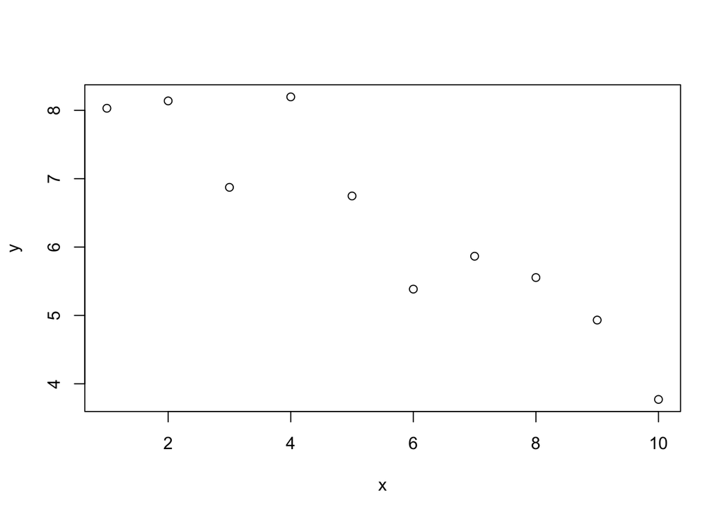

```r
set.seed(1)  # we all generate the same data (you can change this if you like)
N <- 10 # we have 10 data points
x <- 1:N # our x variable is a vector from 1 to 10
y <- 9 + -.5 * x + rnorm(N, 0, .75) # here we simulate the y values based on some linear regression model, and add some random error
plot(x, y) # and we plot our results
```

So, $x$ and $y$ are our data here. For example, $x$ is the number of alcohol beverages someone drinks and $y$ is his/her score on a working memory test.

With the R code `lm(y~poly(x,1))` $^{1}$ we can fit a linear regression model. With the `poly` function we can easily include higher order polynomial and thereby make our model more complex. For example with `lm(y~poly(x,9))` we fit a model were we predict $y$ with $x$, $x^2$, $x^3$, to $x^9$. This polynomial regression model will show a perfect fit to the data, because we use the parameters to describe 10 data points!

1. Note: this code fits the same model as we would fit with: `lm(y ~ 1 + x)` (how can you check?). The only differences is that with the `poly` function we tranform *x* such that if we would include higher order polynomials all transformations of *x* are uncorrelated. For example look at `plot(x, poly(x, 1))`.

#### Question 1

Fit both models (a linear model and a model with a ninth order polynomial) to the data ($x$ and $y$). What is the explained variance in both models? Add two lines to the plot that show the predicted values for both models. ##### Answer

```r
# and some r-code here...
```

#### Question 2

So the polynomial regression model of the ninth order fits perfectly to our data. Why is this the case? The problem is overfitting. Look up a definition of overfitting in the world wide web **and** explain why overfitting is a problem.

##### Answer

#### Question 3

One way to control for overfitting is crossvalidation. Lets look at a simple dataset to examine how crossvalidation works:

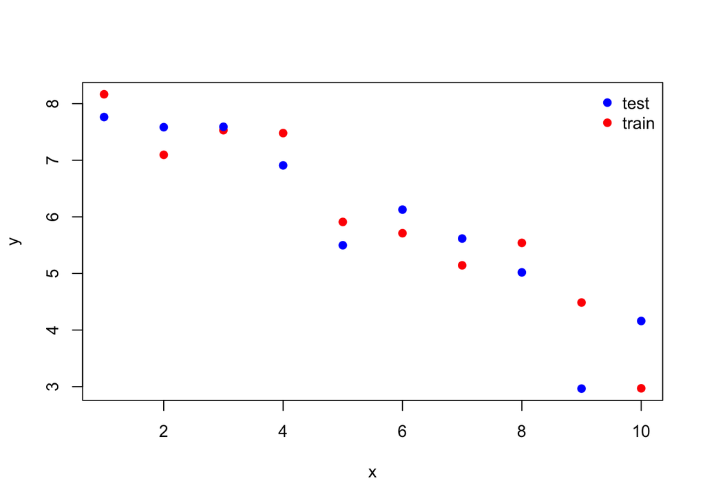

```r
set.seed(1000)
x <- 1:10 # we have the same x
y_train <- 9 + -.5 * x + rnorm(N, 0, .75) # and simulate a training data set
y_test <- 9 + -.5 * x + rnorm(N, 0, .75) # and a test data set according to the same model

# and we put our data in some data frame:
example <- data.frame(x, y_train, y_test)

plot(example$x, example$y_train,
     pch = 19, col = 'red', # and we plot our data:
     ylim = range(c(y_train, y_test)), ylab = 'y', xlab = 'x')
points(example$x, example$y_test,
       pch = 19, col = 'blue')
legend('topright', legend = c('test', 'train'), col = c('blue', 'red'), pch = 19, bty = 'n')
```

So in our example dataset we have a variable `y_train` on which we fit our model and we will use `y_test` to check our results. Following such a procedure is called cross validation (we validate our prediction based on some model on a second test data set). So we have `y_train` and `y_test` and the same *true* model is used to generate both variables.

Fit both models (the linear model and the model with a ninth order polynomial) to the training data. So based on `x` we want to predict `y_train`. What are the predicted values?

##### Answer

#### Question 4

Plot the *test data*. Add two lines that show the predictions of both models that are based on the *training data*. Explain what you see. Did you predict that the prediction line based on the poly(9) model would go through all data points?

##### Answer

#### Question 5

Now we want to quantify how well both models based on the train data predict the test data. Compare the predictions based on the training data to the observations in the test data. To quantify the model fit we can for example look at the variance of the differences between the predictions and the observation. Calculate this for both models.

##### Answer

#### Question 6

So one way to quantify the model fit is to consider the variance between the observations and the predictions (these differences between observations and predictions are called the residuals). However we don’t always have a cross validation sample. Fortunately, we have AIC and BIC. What are the formula’s of the AIC and BIC? Clearly explain how both these fit statistics balance model fit and model complexity.

##### Answer

#### Question 7

##### Answer

#### Question 8 (bonus)

We did our simulation for one specific case `set.seed(1000)`. It would be better to repeat it a couple of times to ensure that indeed in many of our simulations the variance of the residuals is higher for the poly(9) model compared to the linear model. Do this simulation. Make a histogram of the variances of the residuals for both models. Describe what you see.

##### Answer